# Voronoi tesselation

This notebook shows how to perform voronoi tesselation using the `vorbin`package. The following cell is the mandatory data loading.

```python
import astropy.units as u
from xsb_fluc.data.cluster import Cluster

cluster = Cluster(
    imglink='data/A2142/mosaic_a2142.fits.gz',
    explink='data/A2142/mosaic_a2142_expo.fits.gz',
    bkglink='data/A2142/mosaic_a2142_bkg.fits.gz',
    reglink='data/A2142/src_ps.reg',
    nhlink='data/A2142/A2142_nh.fits',
    ra=239.58615,
    dec=27.229433,
    r_500=1.403*u.Mpc,
    redshift=0.09,
)

cluster = cluster.reduce_to_r500(1).rebin(5)
cluster.plot_cluster()
```

```
WARNING: FITSFixedWarning: RADECSYS= 'FK5 ' / Stellar reference frame
the RADECSYS keyword is deprecated, use RADESYSa. [astropy.wcs.wcs]
WARNING: FITSFixedWarning: EQUINOX = '2000.0 ' / Coordinate system equinox
a floating-point value was expected. [astropy.wcs.wcs]
```

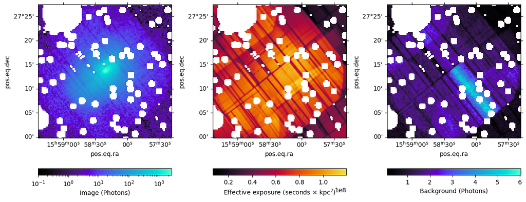

Using this cluster, we can perform a Voronoi tesselation using the implementation from the `vorbin`package, which requires a signal-to-noise function. Here, I do not target a specific SNR but rather a given number of counts (700, which is far greater then what you usually do). The `vorbin` package works with 1D inputs, so we flatten the various data from our cluster. We also filter for pixels that are too far away from the center and that are not exposed.

```python
import numpy as np
from vorbin.voronoi_2d_binning import voronoi_2d_binning

def sn_func(index, signal, noise):

    return np.sum(signal[index])

X,Y = np.indices(cluster.shape)
valid = (cluster.exp>0)&(cluster.coords.separation(cluster.center) < cluster.t_500)

x = X[valid].flatten()
y = Y[valid].flatten()
s = cluster.img[valid].flatten()
n = np.ones_like(s)

bin_number, xBin, yBin, xBar, yBar, sn, nPixels, scale = voronoi_2d_binning(x, y, s, n, 700, pixelsize=1, quiet = True, sn_func=sn_func, plot=False)

np.savetxt('data/A2142/voronoi.txt', bin_number)
```

# Plotting the results

Here I just plot the result. In practice, the image is flattened and reduced to a 1D vector, but this script is made to unflatten it and plot the corresponding Voronoi regions.

```python
import matplotlib.pyplot as plt
import cmasher as cmr
from matplotlib.colors import LogNorm

indexes = (cluster.exp>0)&(cluster.coords.separation(cluster.center) < cluster.t_500)
y_ref, x_ref = cluster.y_ref[indexes], cluster.x_ref[indexes]
img = np.array(cluster.img[indexes].astype(int))
exp = np.array(cluster.exp[indexes].astype(np.float32))

voronoi_img = np.zeros_like(cluster.img)*np.nan
bin_number_img = np.zeros_like(cluster.img)*np.nan
voronoi_img_flat = voronoi_img[indexes]
bin_number_img_flat = np.zeros_like(voronoi_img_flat)

unique_bin = np.unique(bin_number)

for i, number in enumerate(unique_bin):
    bin_index = (bin_number == number)
    voronoi_img_flat[bin_index] = np.sum(img[bin_index])
    bin_number_img_flat[bin_index] = number

voronoi_img[indexes] = voronoi_img_flat
bin_number_img[indexes] = bin_number_img_flat

fig, axs = plt.subplots(
    figsize=(12, 5),
    nrows=1,
    ncols=2,
    subplot_kw={'projection': cluster.wcs}
)

img_plot = axs[0].imshow(voronoi_img, norm=LogNorm(vmin=500), cmap=cmr.cosmic)

plt.colorbar(
    mappable=img_plot,
    ax=axs[0],
    location='bottom',
    label="Image (Photons)"
)

number_plot = axs[1].imshow(bin_number_img, cmap='tab20')

plt.colorbar(
    mappable=number_plot,
    ax=axs[1],
    location='bottom',
    label="Bin number"
)

plt.show();
```

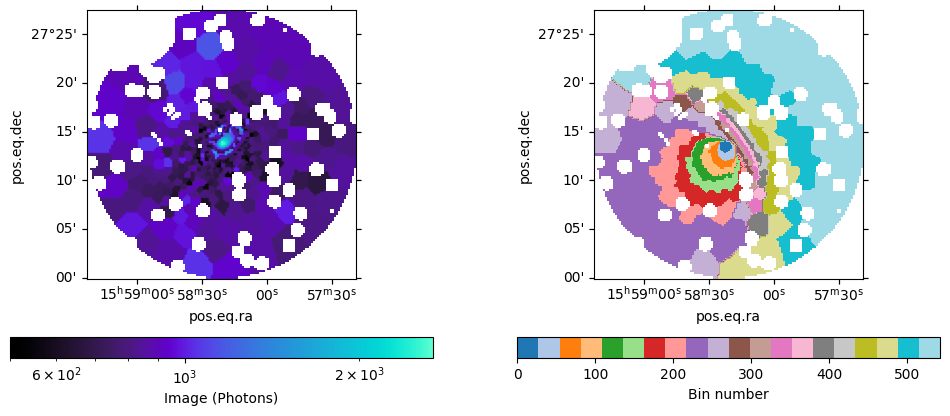